# Assignment 6

## Try to submit as an HTML file

Print your name below

```python
print("David Chen")
```

```
David Chen
```

Import the "pandas" and "matplotlib.pyplot" library

```python
# Write your answer here:
import pandas as pd
import matplotlib.pyplot as plt
```

(a) Compute function for each individual (map)

- Import the datset "data/investment.csv"
- Write a lambda function for $V = P/(1+r)$.
- Use `list(map(...))` to calculate $V$ for each row of the dataset

```python
# Write your own code here
investment = pd.read_csv("data/investment.csv")
compute = lambda P, r : P / (1 + r)
list(map(compute, investment.P, investment.r))
```

```
[990.09900990099,
 1960.7843137254902,
 485.43689320388347,
 769.2307692307692,
 370.3703703703703]
```

For questions (b)-(d), read "data/wdi_2020.csv"

(b) Convert to upper case

- Create the following function to convert a string to upper case

$\quad$ `fn_upper = lambda x: x.upper()`

- Create a new column, "countryname_upper"  
  that converts "countryname" to upper case.

```python
# Write your own code here
wdi_2020 = pd.read_csv("data/wdi_2020.csv")
fn_upper = lambda x : x.upper()
countryname = list(map(fn_upper, wdi_2020.countryname))
print(countryname[0:5])
```

```
['AFGHANISTAN', 'AFRICA EASTERN AND SOUTHERN', 'AFRICA WESTERN AND CENTRAL', 'ALBANIA', 'ALGERIA']
```

(c) Extract sorted elements from a dataset

- Sort by "prop_urbanpopulation" in descending order
- Subset the 5 countries with the highest urban population

```python
# Write your code here
wdi_2020_sorted = wdi_2020.sort_values(by = "prop_urbanpopulation", ascending = False)
top5 = wdi_2020_sorted[0:5]
top5
```

|  | year | yearcode | countryname | countrycode | prop_urbanpopulation |
| --- | --- | --- | --- | --- | --- |
| 212 | 2020 | YR2020 | Singapore | SGP | 100.0 |
| 147 | 2020 | YR2020 | Macao SAR, China | MAC | 100.0 |
| 40 | 2020 | YR2020 | Cayman Islands | CYM | 100.0 |
| 90 | 2020 | YR2020 | Gibraltar | GIB | 100.0 |
| 103 | 2020 | YR2020 | Hong Kong SAR, China | HKG | 100.0 |

(d) Subset elements with query

- Compute the median of "prop_urbanpopulation"
- Use ".query()" to subset countries with  
  "prop_urbanpopulation" above the median

```python
# Write your own code here
median = wdi_2020.prop_urbanpopulation.median()
above_median = wdi_2020.query('prop_urbanpopulation > @median')
above_median.prop_urbanpopulation.describe()
```

```
count    131.000000
mean      79.595212
std       11.532620
min       61.428000
25%       69.398500
50%       80.619059
75%       88.046500
max      100.000000
Name: prop_urbanpopulation, dtype: float64
```

(e) Plot by category

- Read "data/wdi_urban.csv"  
  This contains data from 1980 and 2020
- Create a list with the unique values of "year"
- Create a plot with a ...
  - Histogram of "prop_urbanpopulation"  
    for each year
  - Set the histogram option `alpha = 0.5` for transparency
  - All the histograms should be overlapping
  - Create a legend with the list of years
  - Label the axes and the title

What do we learn from the graph?

HINT: See the example at the end of Lecture 10

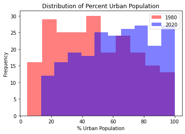

```python
# Write your own code here
wdi_urban = pd.read_csv("data/wdi_urban.csv")
unique_years = wdi_urban.year.unique()
color_map = {1980: "red", 2020: "blue"}

for year in unique_years:
    subset = wdi_urban[wdi_urban["year"] == year]
    plt.hist(subset.prop_urbanpopulation, alpha = 0.5, color = color_map[year])
    plt.xlabel("% Urban Population")
    plt.ylabel("Frequency")
    plt.title(f"Distribution of Percent Urban Population")
plt.legend(["1980", "2020"])

# It's clear from the graph that over the past decades there has been an increase in urbanization, leading more people to live in cities.
```